# Untitled

Jon Frank

2024-03-25

## Befolkningsutvecklingen i Vansbro - en kort analys

I likhet med många mindre kommuner på landsbygden har Vansbros befolkning minskat under en majoritet av åren det senaste decennierna. Runt millennieskiftet var befolkningen nästan 7300 invånare, men har idag minskat till drygt 6700.

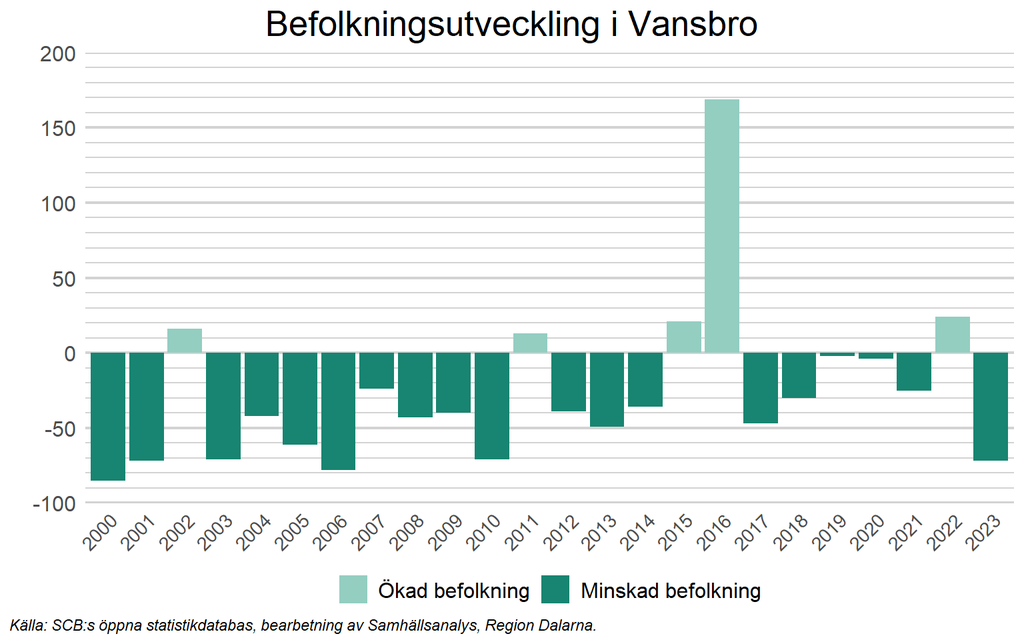

I fortsättningen av denna korta analys delas Vansbros befolkningsutveckling upp i dess komponenter, födelsenetto, dvs. nettot av födda och döda, och flyttnetto, dvs. nettot av inrikes och utrikes flyttar. Vi börjar med födelsenettot.

## Födelsenettot

En tydlig trend är att det dör färre personer i Vansbro idag än det gjorde för ungefär 20 år sedan. Med undantag för Corona-pandemin, 2020 och 2021, så dör idag mellan 80 och 90 personer under ett normalt år i Vansbro. Detta kan jämföras med närmare 120 personer per år i början av 2000-talet. Denna utveckling kan sannolikt härröras till utveckling inom det medicinska området. Befolkningens medelålder ökar över tid och har gjort så länge.

Även när det gäller födslar är trenden negativ, men inte lika tydlig. Under 00-talet föddes relativt ofta över 70 barn i Vansbro, något som inte har hänt sedan 2010. Under 2023 föddes färre barn än 2022, men samtidigt fler än 2021 (och 2018). Det finns dock vissa indikationer på att de låga födelsetalen 2023 är del av en större trend. Enligt SCB har svenskarna inte fött så få barn sedan 1749, en trend som verkar hålla i sig under början av 2024 (Källa: SVT).

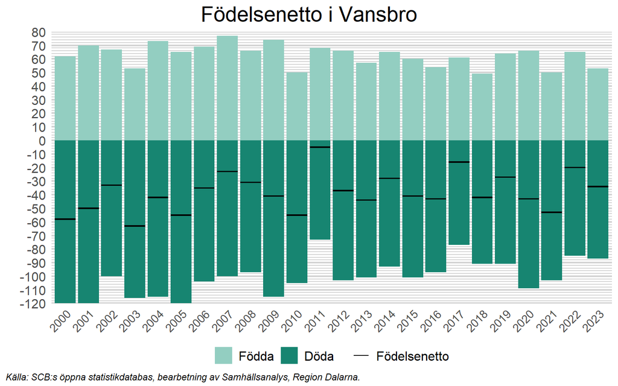